# Lecture 6

# Forecasts

## What can we forecast?

A good forecast approximates the distribution of possible outcomes.

Stocks and exchange rates very hard, drug prices and electricity markets easier, weather hard (depends on physical models), sunrises and eclipses are very easy because we have a physical model of them.

What makes somethign easy v hard to forecast? Easier if:

- we have a good understanding of the factors that contribute to it (e.g., a physical model - sunrise, comets returning).
- there is a lot of data available
- the forecasts cannot affect the thing we are trying to forecast (for example, the prime minister saying soemthing about the price of a stock changes the price of the stock)
- there is relatively low natural/unexplainable random variation (low signal to noise ratio)
- the future is somewhat similar to the past (e.g., forecasting streamflow, but then a da, is built which changes the entire flow regimes)

## The Statistical forecasting perspective

Simulate many possible futures (realizations).

A forecast is a probability distribution of those futures.

It’s nice to show both the realizations and the probability distribution for communication purposes.

Thing to forecast: $y_{T+h}$, want $y$ and some time $T$ that’s $h$ steps ahead of $t$ What we know: $y_1 ... t_T$ Forecast distribution: $y_{T+h | t} = y_{T+h}$

## Benchmark methods

Basically a “null model” that you can compare forecasts to.

**mean**: forecast of all futures equal to mean of observed.

**naive - mean(y)**: forecasts of all futures equal to last observed value. Forecasts: $y_{T+h|t}=y_T$

**Seasonally naive method**: repeat last series over and over again (so forecasted Q1 is last Q1 and so on.), $y_{T+h|t}=y_{T+h-m(k+1)}$.

Random walk with drift - see notes.

`NAIVE, SNAIVE, RW`

```r
library(fpp3)
```

Create the model objects.

[output not shown]

Forecast.

```r
brick_fc <- brick_fit %>%
  forecast(h = "5 years")
brick_fc
```

[output not shown]

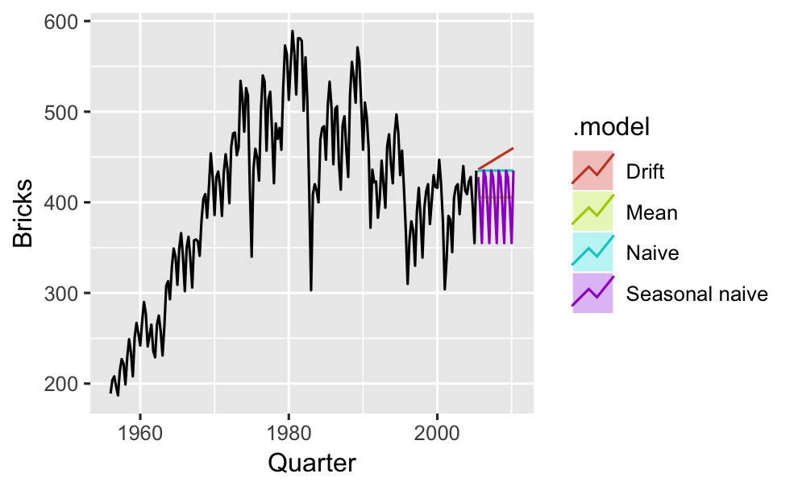

To extract prediction intervals use `hilo()`

```r
brick_fc %>% hilo(level = c(50,70)) %>% unnest()
```

# Lab Session 11

Produce forecasts using an appropriate benchmark method for household wealth (`hh_budget`). Plot results with `autoplot()`.

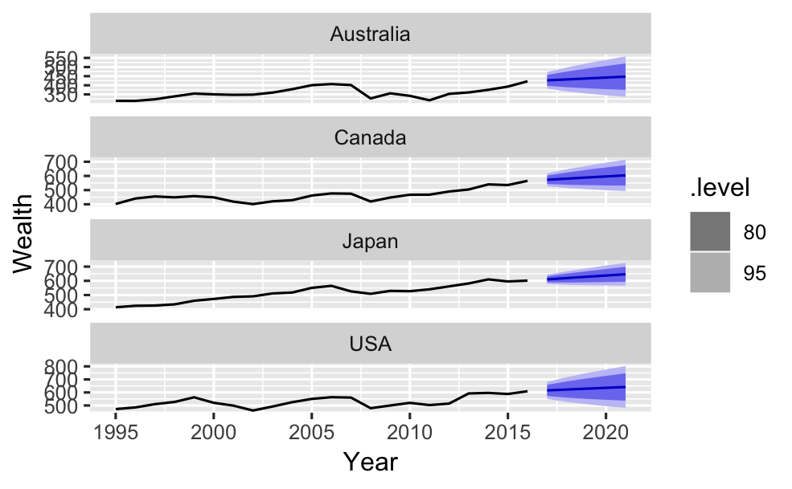

Produce forecasts using an appropriate benchmark method for Australian takeaway food turnover (`aus_retail`). Plot results with `autoplot()`.

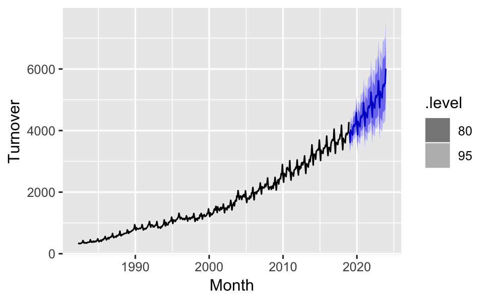

A seasonally naieve method will be a hard benchmark to beat.

# Residual diagnostics

## Assumptions

Aussume uncorrelated errors ${e_t}$. If not, then there is additional information that we’re not exploiting.

${e_t}$ have mean = 0, otherwise the forecasts are biased

## Useful properties

${e_t}$ have constant variance and are normally distributed

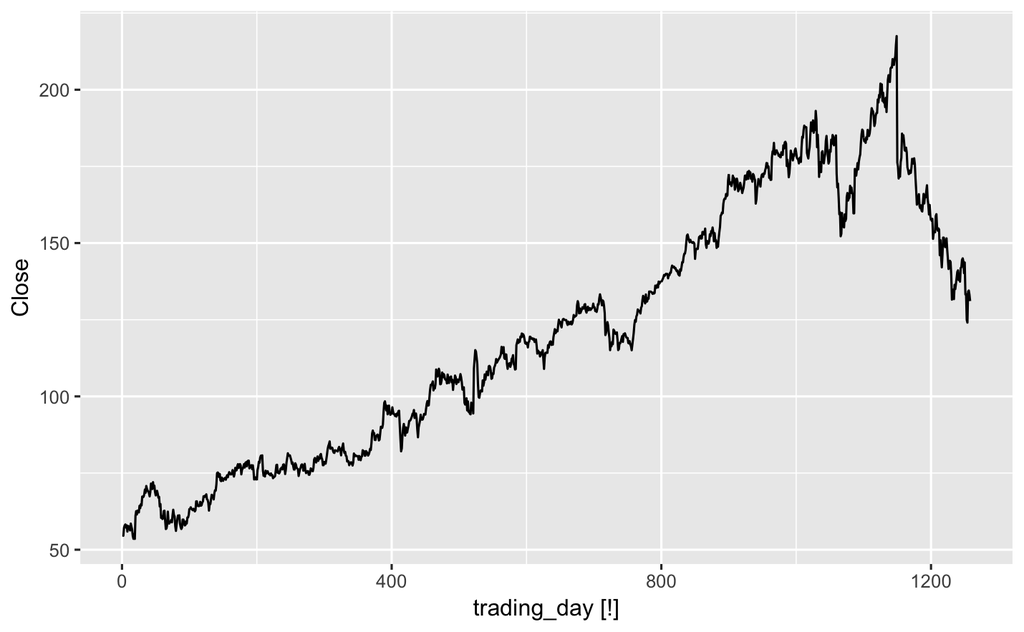

see slides for the rest of this rather long example in checking for correlation between residuals for anaive model.

h = 10 for seasonal data because if you have not seen correlations within 10 lags, you probably won’t thereafter.

Need to enter degrees of freedom `dog` on your own. For naive model it’s 0, but for other models, we need to count.

# Lab session 12

Compute seasonal naieve forecasts for quarterly Australian beer production

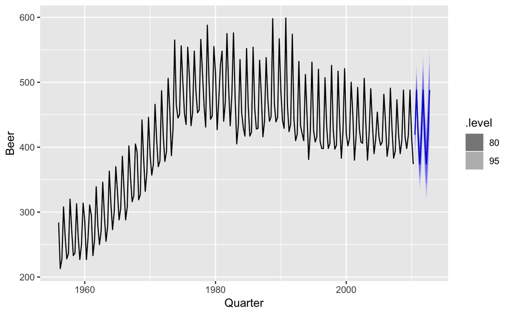

Test of the residuals are white noise. What do you conclude?

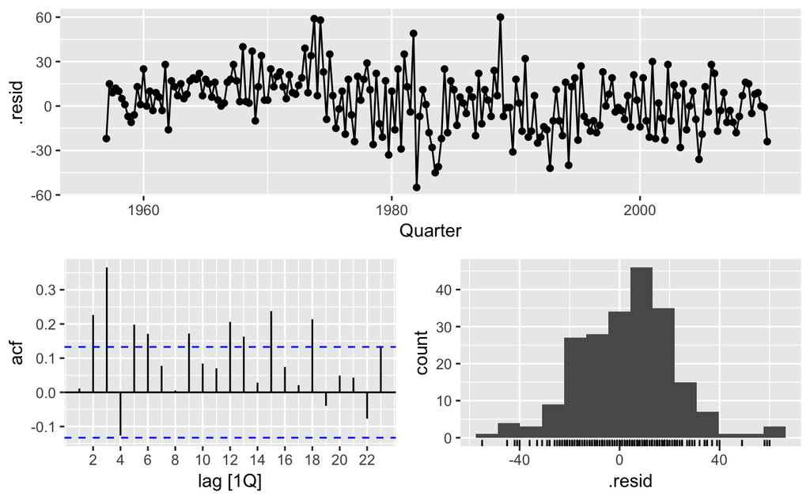

| .model | lb_stat | lb_pvalue |
| --- | --- | --- |
| sn | 60.53466 | 3.66055e-10 |

ACF is clearly positive and significant. See the R script poseted to GH for the Ljung-Box test.

Problem with MAPE (mean absolute percentage error) which is common in business, is that it’s not meaningful for values that are 0 (returns NAN), and not meaningful for values without a natural zero (e.g., termperature or pressure) - what does a percentage mean there?

# Lab session 13

Create a training set for household wealth (hh_budget) withholding the last 4 years as testing data.

Fit all appropriate benchmark methods to the training set to forcast the periods covered by the test set.

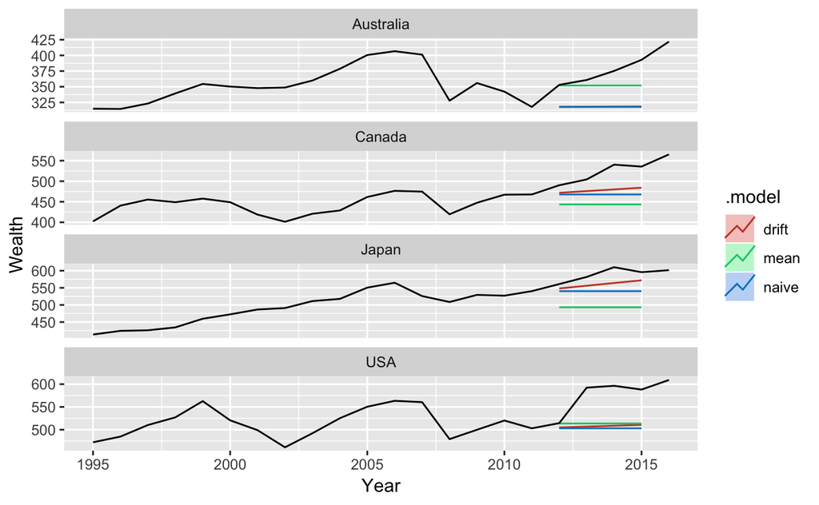

| .model | ME | RMSE | MAE | MPE | MAPE | MASE | ACF1 |
| --- | --- | --- | --- | --- | --- | --- | --- |
| drift | 45.99938 | 49.93221 | 45.99938 | 9.273023 | 9.273023 | 2.392402 | 0.06302548 |
| mean | 61.47140 | 66.24899 | 61.47140 | 11.236938 | 11.236938 | 3.352139 | 0.15186845 |
| naive | 54.81549 | 59.20937 | 54.81549 | 10.828721 | 10.828721 | 2.902380 | 0.15186845 |